# Replication of *Electing Peace: From Civil Conflict to Political Participation* – Aila Matanock

Nick Smith and Nate Mariano

3/21/2018

## Introduction

Why are some settlements of conflict more difficult than others? Because fighting is costlier than peace, combatants in a civil conflict have incentives to sign on to a peace settlement. However, commitment problems—namely the incentives that each side has to renege on a peace deal out of fear that the other will grow stronger during the implementation of the settlement—prevent the successful termination of conflict. Even when it appears that a conflict has been settled and a new government has been established, distributing power between the combatting parties such that the payoff from peace outweighs the benefits from resumed fighting is challenging because of these commitment problems. In the absence of a credible party that could sanction the other side for noncompliance, peace is precarious in the wake of civil conflict.

In Electing Peace: From Civil Conflict to Political Participation (Matanock 2017), Aila Matanock argues that the inclusion of electoral participation agreements (hereafter EPPs) in settlements to civil conflict allows combatants to overcome these commitment problems and contributes to a more durable peace. EPPs are clauses in peace settlements that allow both the government and rebel groups as political parties to compete in post-conflict elections. They are also one way to facilitate the engagement of external actors that can credibly detect and sanction noncompliance on a peace settlement.

In this blog post, we first replicate Matanock’s original results that show an association between settlements that contain EPPs and lower conflict recurrence compared to settlements without such provisions. We then perform a matching function as a robustness check against Matanock’s original results. Though she includes control variables that could make the relationship between EPPs and lower conflict recurrence spurious, we believe there could be unobserved phenomena that drive the main results. We use a matching estimator to correct for this problem.

## Replication

Below is a Kaplan-Meier survival plot that shows the percentage of peace agreements that fail in a given time-span. The plots below show that most peace agreements that fail do so within a few months. However, peace agreements with EPPs tend to have a higher rate of success compared to those agreements without such provisions.

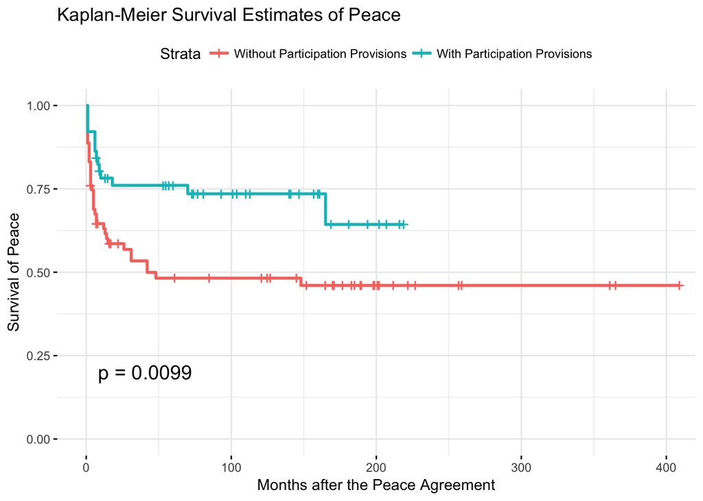

Matanock fits a logistic regression model using a binary indicator of whether the peace agreement ‘fails’ within five years. Failure, in this context, implies that the combatants return to fighting. The main explanatory variable is participation provisions, which is also a binary indicator signifying the inclusion of language that allows combatants to participate in elections side-by-side.

For brevity, we replicate five of Matanock’s original thirteen models. Our replication confirms Matanock’s original finding that settlements containing EPPs are associated with a lower likelihood of conflict recurrence, robust to the inclusion of a variety of covariates. Though the coefficient estimates are slightly different from Matanock’s, they are all signed and significant in the same direction. These differences can be attributed to operating in R instead of Stata.

|  | *Dependent variable:* |  |  |  |  |
| --- | --- | --- | --- | --- | --- |
|  | Conflict Recurrence Within 5 Years |  |  |  |  |
|  | (1) | (2) | (3) | (4) | (5) |
| Participation Provisions | -1.536*** | -1.550*** | -1.877*** | -1.619*** | -1.370** |
|  | (0.559) | (0.579) | (0.531) | (0.600) | (0.665) |
| DDR Provisions |  | -0.876* |  |  | -1.374** |
|  |  | (0.499) |  |  | (0.675) |
| SSR Provisions |  | -0.037 |  |  | -1.060 |
|  |  | (0.499) |  |  | (0.877) |
| Government Power-Sharing Provisions |  | 1.084 |  |  |  |
|  |  | (0.779) |  |  |  |
| Civil Service Power-Sharing Provisions |  | 0.176 |  |  |  |
|  |  | (0.465) |  |  |  |
| Major War |  |  | 1.094 |  | 1.423 |
|  |  |  | (0.733) |  | (1.026) |
| Duration of the Dyad’s Conflict |  |  | -0.003 |  | 0.001 |
|  |  |  | (0.025) |  | (0.033) |
| Real GDP per capita (1000s, lagged) |  |  | 0.037 |  | 0.142 |
|  |  |  | (0.055) |  | (0.095) |
| Balance btwn Group and Government |  |  | -0.459 |  |  |
|  |  |  | (0.459) |  |  |
| Past Agreement(s) |  |  |  | 0.148 |  |
|  |  |  |  | (0.318) |  |
| Number of Factions Not Signing |  |  |  | 0.105 |  |
|  |  |  |  | (0.083) |  |
| Number of Factions Signing |  |  |  | 0.493** | 0.626 |
|  |  |  |  | (0.223) | (0.462) |
| More Negotiations in Agreement |  |  |  | 0.917 | 0.695 |
|  |  |  |  | (0.579) | (1.022) |
| Territorial Conflict |  |  |  |  | -0.811 |
|  |  |  |  |  | (0.973) |
| Rebel Groups with Total Goals |  |  |  |  | -0.320 |
|  |  |  |  |  | (1.027) |
| UN Peacekeeping Mission |  |  |  |  | 0.478 |
|  |  |  |  |  | (1.114) |
| Regional Democracy Level |  |  |  |  | -4.148** |
|  |  |  |  |  | (1.660) |
| Population, 1000s |  |  |  |  | 0.002 |
|  |  |  |  |  | (0.002) |
| Region |  |  |  |  | -1.115 |
|  |  |  |  |  | (0.868) |
| Decade |  |  |  |  | -3.494* |
|  |  |  |  |  | (1.843) |
| Region*Decade |  |  |  |  | 0.942* |
|  |  |  |  |  | (0.495) |
| Constant | 0.236 | 0.493 | -0.0001 | -0.783 | 4.682 |
|  | (0.295) | (0.399) | (0.606) | (0.476) | (4.084) |
| Observations | 110 | 110 | 108 | 110 | 109 |
| Log Likelihood | -68.485 | -65.048 | -63.546 | -64.633 | -51.858 |
| Akaike Inf. Crit. | 140.969 | 142.096 | 139.091 | 141.266 | 137.716 |
| *Note:* | p<0.1; p<0.05; p<0.01 |  |  |  |  |

## Extension: Matching

One potential issue with Matanock’s analysis is the comparability of cases in the treatment and control groups. How comparable are Chad’s 1978 peace agreement and the United Kingdom’s 1998 peace agreement, really? While she controls for observed confounders in her regressions, there remains the possibility that heterogeneity on unobserved differences between cases could be driving the results.

To address this issue, we utilize matching to pair treated units to comparable untreated units. We employ two different matching schemes: first, we match on covariates used by Matanock for which the treatment and control groups were highly dissimilar. The intuition here is that although we are able to control for these dissimilar characteristics in regression, units that are highly dissimilar on these metrics may also be highly dissimilar in unobserved characteristics that we do not control for. These omitted variables could conceivably drive variation on both the IV and DV, compromising the findings. Therefore, comparing cases that are similar on these metrics may help to control for variation on the unobserved characteristics.

We also include variables that drive selection into treatment. As discussed in class, this can allow us to get closer to random assignment to treatment. Matanock shows that a peace agreement is more likely to contain electoral participation provisions if 1) election observers were present in the region in the last year and 2) regional democracy promotion programs were available in the last two years. However, inclusion of EPPs are less likely if the country that is undergoing conflict settlement has special ties to an external power (proxied by oil production). So, we also separately match on these three variables. For both analyses, we use the default matching technique in the “Match” function, which assigns weights equal to the inverse of the variances.

### Matching: Disparate Covariates

The tables below show the balance on the covariates for which the treatment and control groups are highly dissimilar, before and after matching. We can see that matching erases many of the statistically significant differences between the groups, although DDR Provisions remains significantly different.

Treated/Untreated Balance Table - Disparate

|  | mean.Tr | mean.Co | sdiff | T pval |
| --- | --- | --- | --- | --- |
| DDR Provisions | 0.7380952 | 0.3676471 | 83.24667 | 0.0000902 |
| SSR Provisions | 0.7380952 | 0.3382353 | 89.85604 | 0.0000237 |
| Major War | 0.8571429 | 0.6764706 | 51.01304 | 0.0243607 |
| GDP per Capita | 2.1587098 | 2.7266138 | -13.49631 | 0.5060442 |
| Regional Democracy Level | 0.3461466 | 0.3085401 | 19.05039 | 0.3730135 |
| Cold War | 0.0000000 | 0.2058824 | -Inf | 0.0000902 |
| Population | 21.6519060 | 57.3565099 | -95.53160 | 0.1060443 |
| Territorial Dispute | 0.1666667 | 0.3970588 | -61.08031 | 0.0068146 |

Treated/Matched Balance Table - Disparate

|  | mean.Tr | mean.Co | sdiff | T pval |
| --- | --- | --- | --- | --- |
| DDR Provisions | 0.7380952 | 0.6428571 | 21.401789 | 0.0416813 |
| SSR Provisions | 0.7380952 | 0.6666667 | 16.051342 | 0.0796346 |
| Major War | 0.8571429 | 0.8571429 | 0.000000 | 1.0000000 |
| GDP per Capita | 2.1587098 | 2.0378624 | 2.871955 | 0.5147919 |
| Regional Democracy Level | 0.3461466 | 0.3216647 | 12.401824 | 0.1412186 |
| Cold War | 0.0000000 | 0.0000000 | 0.000000 | 1.0000000 |
| Population | 21.6519060 | 19.0878132 | 6.860513 | 0.4752550 |
| Territorial Dispute | 0.1666667 | 0.1666667 | 0.000000 | 1.0000000 |

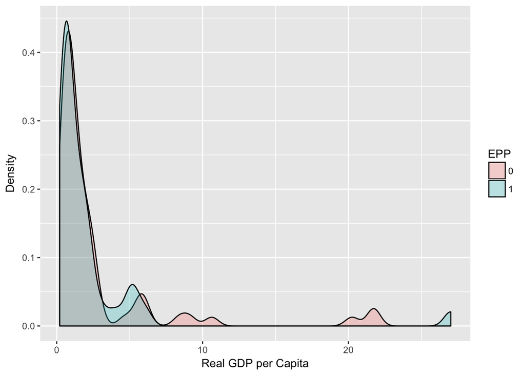

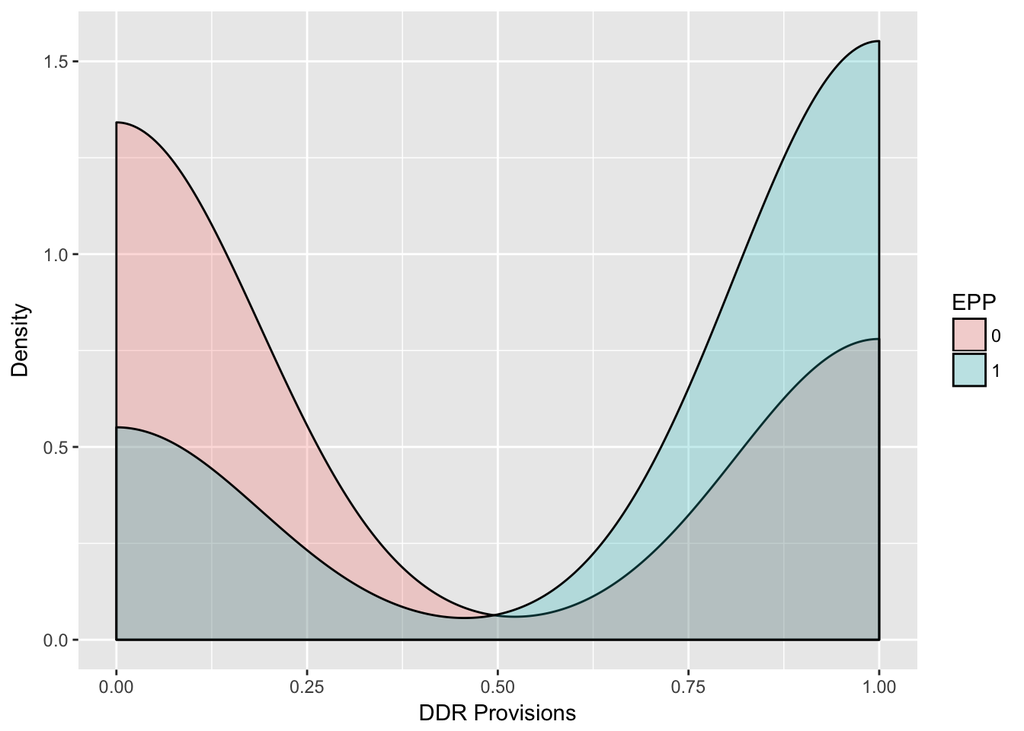

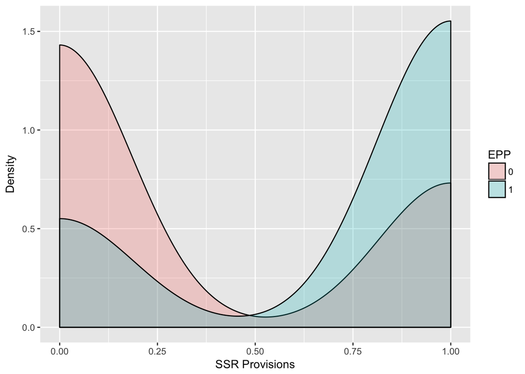

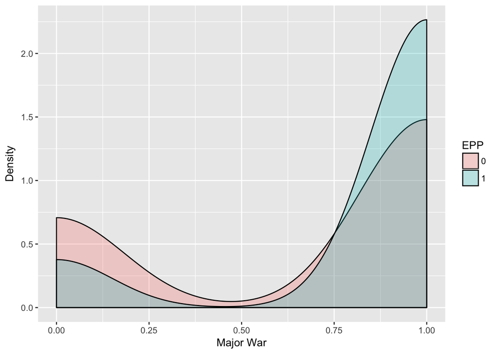

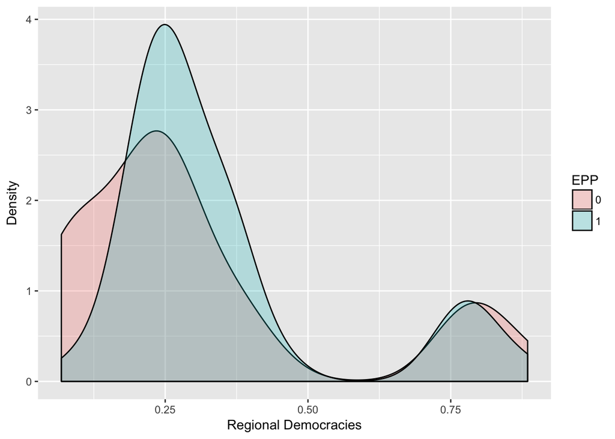

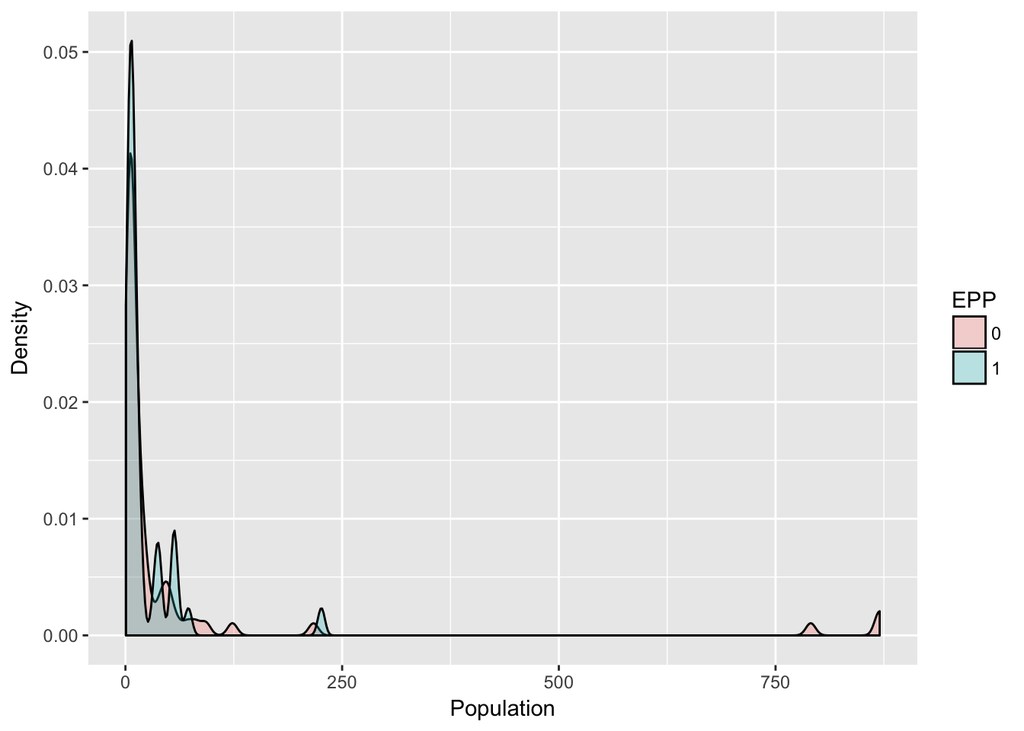

```r
# Multiple plot function
#
# ggplot objects can be passed in ..., or to plotlist (as a list of ggplot objects)
# - cols:   Number of columns in layout
# - layout: A matrix specifying the layout. If present, 'cols' is ignored.
#
# If the layout is something like matrix(c(1,2,3,3), nrow=2, byrow=TRUE),
# then plot 1 will go in the upper left, 2 will go in the upper right, and
# 3 will go all the way across the bottom.
#
multiplot <- function(..., plotlist=NULL, file, cols=1, layout=NULL) {
  library(grid)

  # Make a list from the ... arguments and plotlist
  plots <- c(list(...), plotlist)

  numPlots = length(plots)

  # If layout is NULL, then use 'cols' to determine layout
  if (is.null(layout)) {
    # Make the panel
    # ncol: Number of columns of plots
    # nrow: Number of rows needed, calculated from # of cols
    layout <- matrix(seq(1, cols * ceiling(numPlots/cols)),
                    ncol = cols, nrow = ceiling(numPlots/cols))
  }

 if (numPlots==1) {
    print(plots[[1]])

  } else {
    # Set up the page
    grid.newpage()
    pushViewport(viewport(layout = grid.layout(nrow(layout), ncol(layout))))

    # Make each plot, in the correct location
    for (i in 1:numPlots) {
      # Get the i,j matrix positions of the regions that contain this subplot
      matchidx <- as.data.frame(which(layout == i, arr.ind = TRUE))

      print(plots[[i]], vp = viewport(layout.pos.row = matchidx$row,
                                      layout.pos.col = matchidx$col))
    }
  }
}
```

### Matching: Selection into Treatment

The tables below show the balance on the covariates that predict selection into treatment, before and after matching. The highly significant difference in Regional Election Observation goes away.

Treated/Untreated Balance Table - Selection

|  | mean.Tr | mean.Co | sdiff | T pval |
| --- | --- | --- | --- | --- |
| Regional Election Observation | 0.7318740 | 0.5135419 | 96.22632 | 0.0000718 |
| Regional Dem/Gov Assistance | 0.3461466 | 0.3085401 | 19.05039 | 0.3730135 |
| Oil Production | 0.4047619 | 0.4852941 | -16.21033 | 0.4134499 |

Treated/Matched Balance Table - Selection

|  | mean.Tr | mean.Co | sdiff | T pval |
| --- | --- | --- | --- | --- |
| Regional Election Observation | 0.7318740 | 0.7378453 | -2.631742 | 0.6045614 |
| Regional Dem/Gov Assistance | 0.3461466 | 0.3504059 | -2.157628 | 0.2317761 |
| Oil Production | 0.4047619 | 0.4047619 | 0.000000 | 1.0000000 |

### Results

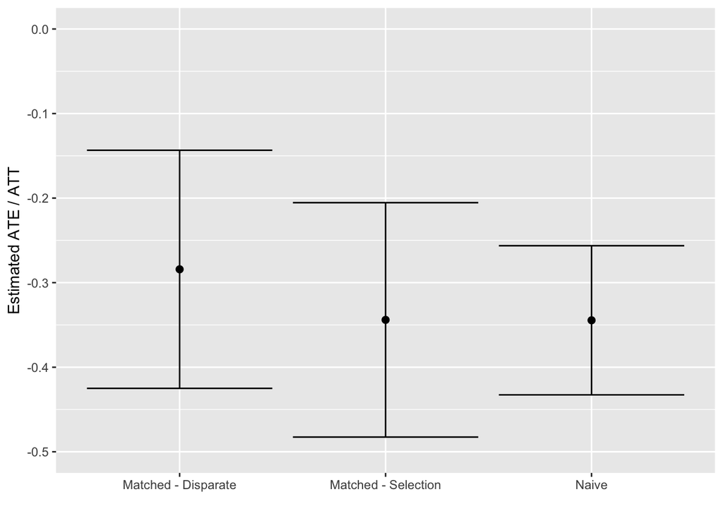

The plot of the results above compares the naive estimate of the ATE to the matched estimates of the ATT, using each matching technique. The effect of EPPs on the likelihood of failure of the peace agreement within five years remains negative and statistically significant for each specification.

## Conclusion

In brief, we successfully replicated Matanock’s main finding that peace agreements which contain electoral participation provisions result in lower levels of conflict recurrence. Though Matanock controls for relevant factors that may yield specious results, we were still concerned her regression models may not have captured unobserved factors that would lead to findings that counter her main claims.

## Reference

Matanock, Aila. 2017. Electing Peace: From Civil Conflict to Political Participation